# Survivor - Sentiment Multilevel Modeling

Helen Schmidt

2022-01-26

```r
library(tidyverse)
library(tidytext)
library(dplyr)
library(knitr)
library(readr)
library(wordcloud)
library(wordcloud2)
library(RColorBrewer)
library(tm)
library(SnowballC)
library(XML)
library(RCurl)
library(ggpubr)
library(wesanderson)
library(reshape2)
library(MetBrewer)
library(sentimentr)
library(sna)
library(splitstackshape)
library(GGally)
library(ggraph)
library(gutenbergr)
library(igraph)
library(Matrix)
library(network)
library(tidygraph)
library(tibble)
library(formattable)
library(forcats)
library(lme4)
library(ggthemes)
library(lmerTest)
library(misty)
library(Rmisc)
library(effects)
library(arm)
library(sjPlot)
library(lattice)
library(devtools)
#devtools::install_github("strengejacke/sjPlot", force = TRUE)
library(sjPlot)
se <- function(x) sqrt(var(x)/length(x))  #function to calculate SE
```

### Load cleaned dataframe of sentiment + choice data

```r
# define color palette
# colors <- met.brewer("Hiroshige", 7, type = "discrete")
# palette <- met.brewer("Hiroshige", 25, type = "continuous")

## ----- LOAD CLEANED DATA ----- ##
#data.allChoices <- read.csv("NAs_survivor_data_cleaned.csv") #as a tibble
data <- read.csv("survivor_data_cleaned.csv")
head(data)
```

|  | PID | Block_Type | Block_Number | Target | Choice | Percent_Time_Chosen | Target_Mean_Sentiment | Choice_Mean_Sentiment | Target.Choice_Sentiment_Cumulative | Target.Choice_Sentiment_Recent | Target.Choice_Sentiment_Overall | Choice.Target_Sentiment_Cumulative | Choice.Target_Sentiment_Recent | Choice.Target_Sentiment_Overall |
| --- | --- | --- | --- | --- | --- | --- | --- | --- | --- | --- | --- | --- | --- | --- |
| 1 | 1 | Friend | 5 | Amber | Rob | 1.0 | 0.07010708 | 0.04551586 | -0.02777778 | -0.041666667 | -0.02777778 | -0.02922959 | 0.009635872 | 0.01259754 |
| 2 | 1 | Friend | 5 | Amber | ShiiAnn | 0.2 | 0.07010708 | 0.08696752 | 0.19445436 | 0.194454365 | 0.19445436 | 0.18452780 | 0.184527797 | 0.18452780 |
| 3 | 1 | Friend | 5 | Rob | Amber | 1.0 | 0.04551586 | 0.07010708 | -0.02922959 | 0.009635872 | 0.01259754 | -0.02777778 | -0.041666667 | -0.02777778 |
| 4 | 1 | Friend | 5 | Rupert | ShiiAnn | 0.2 | 0.11260331 | 0.08696752 | -0.01087796 | 0.042163702 | -0.01087796 | 0.01926200 | 0.010008016 | 0.01926200 |
| 5 | 1 | Friend | 5 | ShiiAnn | Amber | 0.8 | 0.08696752 | 0.07010708 | 0.18452780 | 0.184527797 | 0.18452780 | 0.19445436 | 0.194454365 | 0.19445436 |
| 6 | 1 | Friend | 5 | ShiiAnn | Rupert | 0.4 | 0.08696752 | 0.11260331 | 0.01926200 | 0.010008016 | 0.01926200 | -0.01087796 | 0.042163702 | -0.01087796 |

### Define model parameters

> Dependent variable = Percent_Time_Chosen  
> Fixed effects = Block_Number  
> Interaction effects = Sentiment * Block_Type  
> Random effects = Block_Number  
> Random effect grouped by Block_Type = PID

3 types of sentiment scores - most recent, cumulative, & overall  
2 types of models per sentiment score type - target-choice & choice-target

### Overall sentiment ~ % time chosen

How well does overall sentiment between target + choice predict percent of time chosen?

#### First, I’ll fit a linear mixed-effects model to my choice behavior + sentiment score data.

I run two models - one to compare target-choice sentiment to percent of time chosen and the other to compare choice-target sentiment to percent of time chosen.

```r
## run the model
# How does overall sentiment predict percent of time chosen?
print("Target-Choice Model")
```

```
## [1] "Target-Choice Model"
```

```r
mlm2 <- lmer(Percent_Time_Chosen ~ Target.Choice_Sentiment_Overall * Block_Type + Block_Number + (Block_Type|PID) + (1|Block_Number), data = data)
# get coefficient estimates and coefficient SEs; pull error terms from group and residual to calculate ICC based on model output (intercept SD/intercept SD + residual SD)
display(mlm2)
```

```
## lmer(formula = Percent_Time_Chosen ~ Target.Choice_Sentiment_Overall *
##     Block_Type + Block_Number + (Block_Type | PID) + (1 | Block_Number),
##     data = data)
##                                                 coef.est coef.se
## (Intercept)                                      0.59     0.05
## Target.Choice_Sentiment_Overall                 -0.11     0.13
## Block_TypeRival                                 -0.09     0.02
## Block_TypeWin                                    0.00     0.02
## Block_Number                                    -0.01     0.01
## Target.Choice_Sentiment_Overall:Block_TypeRival  0.19     0.18
## Target.Choice_Sentiment_Overall:Block_TypeWin   -0.07     0.21
##
## Error terms:
##  Groups       Name            Std.Dev. Corr
##  PID          (Intercept)     0.00
##               Block_TypeRival 0.00      1.00
##               Block_TypeWin   0.00     -0.98 -0.98
##  Block_Number (Intercept)     0.04
##  Residual                     0.34
## ---
## number of obs: 1564, groups: PID, 46; Block_Number, 5
## AIC = 1089.7, DIC = 996
## deviance = 1027.8
```

```r
print("Choice-Target Model")
```

```
## [1] "Choice-Target Model"
```

```r
mlm3 <- lmer(Percent_Time_Chosen ~ Choice.Target_Sentiment_Overall * Block_Type + Block_Number + (Block_Type|PID) + (1|Block_Number), data = data)
display(mlm3)
```

```
## lmer(formula = Percent_Time_Chosen ~ Choice.Target_Sentiment_Overall *
##     Block_Type + Block_Number + (Block_Type | PID) + (1 | Block_Number),
##     data = data)
##                                                 coef.est coef.se
## (Intercept)                                      0.60     0.05
## Choice.Target_Sentiment_Overall                 -0.44     0.13
## Block_TypeRival                                 -0.11     0.02
## Block_TypeWin                                    0.01     0.02
## Block_Number                                    -0.01     0.01
## Choice.Target_Sentiment_Overall:Block_TypeRival  0.66     0.18
## Choice.Target_Sentiment_Overall:Block_TypeWin   -0.37     0.21
##
## Error terms:
##  Groups       Name            Std.Dev. Corr
##  PID          (Intercept)     0.00
##               Block_TypeRival 0.00      NaN
##               Block_TypeWin   0.00      NaN 0.94
##  Block_Number (Intercept)     0.04
##  Residual                     0.33
## ---
## number of obs: 1564, groups: PID, 46; Block_Number, 5
## AIC = 1053.3, DIC = 960
## deviance = 991.6
```

#### Now, I’ll get a summary table of my model showing the estimates for my fixed effects, standard error, df, t values, and significance levels.

```r
# get fixed effects table with estimate, SE, df, t value, and significance
print("Target-Choice Model")
```

```
## [1] "Target-Choice Model"
```

```r
summary(mlm2)
```

```
## Linear mixed model fit by REML. t-tests use Satterthwaite's method [
## lmerModLmerTest]
## Formula: Percent_Time_Chosen ~ Target.Choice_Sentiment_Overall * Block_Type +
##     Block_Number + (Block_Type | PID) + (1 | Block_Number)
##    Data: data
##
## REML criterion at convergence: 1059.7
##
## Scaled residuals:
##      Min       1Q   Median       3Q      Max
## -1.88582 -0.89111  0.08292  0.80217  1.64544
##
## Random effects:
##  Groups       Name            Variance  Std.Dev.  Corr
##  PID          (Intercept)     3.577e-10 1.891e-05
##               Block_TypeRival 6.666e-12 2.582e-06  1.00
##               Block_TypeWin   1.377e-09 3.711e-05 -0.98 -0.98
##  Block_Number (Intercept)     1.306e-03 3.614e-02
##  Residual                     1.130e-01 3.361e-01
## Number of obs: 1564, groups:  PID, 46; Block_Number, 5
##
## Fixed effects:
##                                                   Estimate Std. Error
## (Intercept)                                      5.936e-01  4.668e-02
## Target.Choice_Sentiment_Overall                 -1.109e-01  1.325e-01
## Block_TypeRival                                 -8.784e-02  2.263e-02
## Block_TypeWin                                   -9.684e-04  2.394e-02
## Block_Number                                    -7.405e-03  1.330e-02
## Target.Choice_Sentiment_Overall:Block_TypeRival  1.853e-01  1.825e-01
## Target.Choice_Sentiment_Overall:Block_TypeWin   -6.642e-02  2.091e-01
##                                                         df t value Pr(>|t|)
## (Intercept)                                      3.966e+00  12.715 0.000232 ***
## Target.Choice_Sentiment_Overall                  1.556e+03  -0.837 0.402958
## Block_TypeRival                                  1.556e+03  -3.881 0.000109 ***
## Block_TypeWin                                    1.445e+03  -0.040 0.967738
## Block_Number                                     3.186e+00  -0.557 0.614547
## Target.Choice_Sentiment_Overall:Block_TypeRival  1.554e+03   1.016 0.309991
## Target.Choice_Sentiment_Overall:Block_TypeWin    1.557e+03  -0.318 0.750813
## ---
## Signif. codes:  0 '***' 0.001 '**' 0.01 '*' 0.05 '.' 0.1 ' ' 1
##
## Correlation of Fixed Effects:
##              (Intr) Tr.C_S_O Blc_TR Blc_TW Blck_N T.C_S_O:B_TR
## Trgt.Ch_S_O  -0.115
## Blck_TypRvl  -0.252  0.300
## Block_TypWn  -0.266  0.280    0.489
## Block_Numbr  -0.870 -0.037    0.006  0.023
## T.C_S_O:B_TR  0.108 -0.711   -0.415 -0.212  0.001
## T.C_S_O:B_TW  0.096 -0.620   -0.198 -0.431  0.001  0.453
## optimizer (nloptwrap) convergence code: 0 (OK)
## boundary (singular) fit: see ?isSingular
```

```r
print("Choice-Target Model")
```

```
## [1] "Choice-Target Model"
```

```r
summary(mlm3)
```

```
## Linear mixed model fit by REML. t-tests use Satterthwaite's method [
## lmerModLmerTest]
## Formula: Percent_Time_Chosen ~ Choice.Target_Sentiment_Overall * Block_Type +
##     Block_Number + (Block_Type | PID) + (1 | Block_Number)
##    Data: data
##
## REML criterion at convergence: 1023.3
##
## Scaled residuals:
##      Min       1Q   Median       3Q      Max
## -2.22237 -0.84802  0.05345  0.84476  1.82735
##
## Random effects:
##  Groups       Name            Variance  Std.Dev.  Corr
##  PID          (Intercept)     0.000e+00 0.000e+00
##               Block_TypeRival 3.063e-10 1.750e-05  NaN
##               Block_TypeWin   3.277e-11 5.725e-06  NaN 0.94
##  Block_Number (Intercept)     1.578e-03 3.972e-02
##  Residual                     1.103e-01 3.322e-01
## Number of obs: 1564, groups:  PID, 46; Block_Number, 5
##
## Fixed effects:
##                                                   Estimate Std. Error
## (Intercept)                                      6.038e-01  4.963e-02
## Choice.Target_Sentiment_Overall                 -4.374e-01  1.310e-01
## Block_TypeRival                                 -1.114e-01  2.237e-02
## Block_TypeWin                                    1.217e-02  2.368e-02
## Block_Number                                    -5.515e-03  1.426e-02
## Choice.Target_Sentiment_Overall:Block_TypeRival  6.612e-01  1.803e-01
## Choice.Target_Sentiment_Overall:Block_TypeWin   -3.700e-01  2.067e-01
##                                                         df t value Pr(>|t|)
## (Intercept)                                      3.713e+00  12.166 0.000398 ***
## Choice.Target_Sentiment_Overall                  1.557e+03  -3.339 0.000860 ***
## Block_TypeRival                                  1.556e+03  -4.978 7.15e-07 ***
## Block_TypeWin                                    1.478e+03   0.514 0.607310
## Block_Number                                     3.072e+00  -0.387 0.724111
## Choice.Target_Sentiment_Overall:Block_TypeRival  1.554e+03   3.667 0.000254 ***
## Choice.Target_Sentiment_Overall:Block_TypeWin    1.557e+03  -1.790 0.073631 .
## ---
## Signif. codes:  0 '***' 0.001 '**' 0.01 '*' 0.05 '.' 0.1 ' ' 1
##
## Correlation of Fixed Effects:
##              (Intr) Ch.T_S_O Blc_TR Blc_TW Blck_N C.T_S_O:B_TR
## Chc.Trg_S_O  -0.107
## Blck_TypRvl  -0.234  0.300
## Block_TypWn  -0.248  0.279    0.488
## Block_Numbr  -0.874 -0.033    0.006  0.021
## C.T_S_O:B_TR  0.100 -0.711   -0.415 -0.212  0.000
## C.T_S_O:B_TW  0.089 -0.619   -0.198 -0.432  0.001  0.453
## optimizer (nloptwrap) convergence code: 0 (OK)
## boundary (singular) fit: see ?isSingular
```

#### Now, I’ll examine the coefficients in my model.

```r
## examine the coefficients
print("Target-Choice Model")
```

```
## [1] "Target-Choice Model"
```

```r
coef(mlm2)
```

```
## $PID
##    (Intercept) Target.Choice_Sentiment_Overall Block_TypeRival Block_TypeWin
## 1    0.5935528                      -0.1108719     -0.08783517 -0.0009684367
## 2    0.5935528                      -0.1108719     -0.08783517 -0.0009684362
## 3    0.5935528                      -0.1108719     -0.08783517 -0.0009684336
## 4    0.5935528                      -0.1108719     -0.08783517 -0.0009684238
## 5    0.5935528                      -0.1108719     -0.08783517 -0.0009684362
## 6    0.5935528                      -0.1108719     -0.08783517 -0.0009684490
## 7    0.5935528                      -0.1108719     -0.08783517 -0.0009684433
## 8    0.5935528                      -0.1108719     -0.08783517 -0.0009684453
## 9    0.5935528                      -0.1108719     -0.08783517 -0.0009684366
## 10   0.5935528                      -0.1108719     -0.08783517 -0.0009684628
## 11   0.5935528                      -0.1108719     -0.08783517 -0.0009684423
## 12   0.5935528                      -0.1108719     -0.08783517 -0.0009684307
## 13   0.5935528                      -0.1108719     -0.08783517 -0.0009684378
```

[output cut: 150 more lines]

```r
fixef(mlm2)
```

```
##                                     (Intercept)
##                                    0.5935527912
##                 Target.Choice_Sentiment_Overall
##                                   -0.1108719068
##                                 Block_TypeRival
##                                   -0.0878351671
##                                   Block_TypeWin
##                                   -0.0009684355
##                                    Block_Number
##                                   -0.0074048966
## Target.Choice_Sentiment_Overall:Block_TypeRival
##                                    0.1853169396
##   Target.Choice_Sentiment_Overall:Block_TypeWin
##                                   -0.0664152959
```

```r
ranef(mlm2)
```

```
## $PID
##      (Intercept) Block_TypeRival Block_TypeWin
## 1   6.854291e-10    9.356800e-11 -1.185327e-09
## 2   3.775709e-10    5.154224e-11 -6.760832e-10
## 3  -1.425638e-09   -1.946141e-10  1.974624e-09
## 4  -5.990834e-09   -8.178094e-10  1.172055e-08
## 5   3.042992e-10    4.153992e-11 -6.988858e-10
## 6   6.724797e-09    9.180028e-10 -1.349481e-08
## 7   3.826581e-09    5.223669e-10 -7.741721e-09
## 8   5.072932e-09    6.925065e-10 -9.729419e-09
## 9   6.902395e-10    9.422467e-11 -1.027318e-09
## 10  1.388878e-08    1.895959e-09 -2.725552e-08
## 11  3.590297e-09    4.901118e-10 -6.795950e-09
## 12 -2.709184e-09   -3.698310e-10  4.862410e-09
## 13  1.319509e-09    1.801264e-10 -2.294490e-09
```

[output cut: 43 more lines]

```r
se.fixef(mlm2)
```

```
##                                     (Intercept)
##                                      0.04668122
##                 Target.Choice_Sentiment_Overall
##                                      0.13253008
##                                 Block_TypeRival
##                                      0.02263402
##                                   Block_TypeWin
##                                      0.02393993
##                                    Block_Number
##                                      0.01330473
## Target.Choice_Sentiment_Overall:Block_TypeRival
##                                      0.18247537
##   Target.Choice_Sentiment_Overall:Block_TypeWin
##                                      0.20910073
```

```r
se.ranef(mlm2)
```

```
## $PID
##    (Intercept) Block_TypeRival Block_TypeWin
## 1  1.89127e-05    2.581775e-06   3.71089e-05
## 2  1.89127e-05    2.581775e-06   3.71089e-05
## 3  1.89127e-05    2.581775e-06   3.71089e-05
## 4  1.89127e-05    2.581775e-06   3.71089e-05
## 5  1.89127e-05    2.581775e-06   3.71089e-05
## 6  1.89127e-05    2.581775e-06   3.71089e-05
## 7  1.89127e-05    2.581775e-06   3.71089e-05
## 8  1.89127e-05    2.581775e-06   3.71089e-05
## 9  1.89127e-05    2.581775e-06   3.71089e-05
## 10 1.89127e-05    2.581775e-06   3.71089e-05
## 11 1.89127e-05    2.581775e-06   3.71089e-05
## 12 1.89127e-05    2.581775e-06   3.71089e-05
## 13 1.89127e-05    2.581775e-06   3.71089e-05
```

[output cut: 41 more lines]

```r
print("Choice-Target Model")
```

```
## [1] "Choice-Target Model"
```

```r
coef(mlm3)
```

```
## $PID
##    (Intercept) Choice.Target_Sentiment_Overall Block_TypeRival Block_TypeWin
## 1    0.6037618                      -0.4374266      -0.1113671    0.01217416
## 2    0.6037618                      -0.4374266      -0.1113671    0.01217416
## 3    0.6037618                      -0.4374266      -0.1113671    0.01217416
## 4    0.6037618                      -0.4374266      -0.1113671    0.01217416
## 5    0.6037618                      -0.4374266      -0.1113671    0.01217416
## 6    0.6037618                      -0.4374266      -0.1113671    0.01217416
## 7    0.6037618                      -0.4374266      -0.1113671    0.01217416
## 8    0.6037618                      -0.4374266      -0.1113671    0.01217416
## 9    0.6037618                      -0.4374266      -0.1113671    0.01217416
## 10   0.6037618                      -0.4374266      -0.1113671    0.01217416
## 11   0.6037618                      -0.4374266      -0.1113671    0.01217416
## 12   0.6037618                      -0.4374266      -0.1113671    0.01217416
## 13   0.6037618                      -0.4374266      -0.1113671    0.01217416
```

[output cut: 150 more lines]

```r
fixef(mlm3)
```

```
##                                     (Intercept)
##                                     0.603761791
##                 Choice.Target_Sentiment_Overall
##                                    -0.437426554
##                                 Block_TypeRival
##                                    -0.111367114
##                                   Block_TypeWin
##                                     0.012174164
##                                    Block_Number
##                                    -0.005514808
## Choice.Target_Sentiment_Overall:Block_TypeRival
##                                     0.661185735
##   Choice.Target_Sentiment_Overall:Block_TypeWin
##                                    -0.369955739
```

```r
ranef(mlm3)
```

```
## $PID
##    (Intercept) Block_TypeRival Block_TypeWin
## 1            0    1.167789e-09  3.678149e-10
## 2            0    1.543352e-09  4.751660e-10
## 3            0   -5.066089e-09 -1.615845e-09
## 4            0   -6.041540e-11 -3.499479e-12
## 5            0   -2.951358e-09 -9.160635e-10
## 6            0    2.914243e-09  8.509803e-10
## 7            0   -1.688989e-09 -5.516229e-10
## 8            0    9.976902e-10  3.084019e-10
## 9            0    2.719299e-09  8.674996e-10
## 10           0    1.909319e-09  5.401743e-10
## 11           0    6.123354e-10  1.953350e-10
## 12           0   -3.014016e-09 -9.575700e-10
## 13           0    2.286481e-09  7.228165e-10
```

[output cut: 43 more lines]

```r
se.fixef(mlm3)
```

```
##                                     (Intercept)
##                                      0.04962722
##                 Choice.Target_Sentiment_Overall
##                                      0.13100023
##                                 Block_TypeRival
##                                      0.02237332
##                                   Block_TypeWin
##                                      0.02368391
##                                    Block_Number
##                                      0.01425572
## Choice.Target_Sentiment_Overall:Block_TypeRival
##                                      0.18033011
##   Choice.Target_Sentiment_Overall:Block_TypeWin
##                                      0.20666690
```

```r
se.ranef(mlm3)
```

```
## $PID
##    (Intercept) Block_TypeRival Block_TypeWin
## 1            0     1.75006e-05  5.724869e-06
## 2            0     1.75006e-05  5.724869e-06
## 3            0     1.75006e-05  5.724869e-06
## 4            0     1.75006e-05  5.724869e-06
## 5            0     1.75006e-05  5.724869e-06
## 6            0     1.75006e-05  5.724869e-06
## 7            0     1.75006e-05  5.724869e-06
## 8            0     1.75006e-05  5.724869e-06
## 9            0     1.75006e-05  5.724869e-06
## 10           0     1.75006e-05  5.724869e-06
## 11           0     1.75006e-05  5.724869e-06
## 12           0     1.75006e-05  5.724869e-06
## 13           0     1.75006e-05  5.724869e-06
```

[output cut: 41 more lines]

#### Now, I’m going to test my model against a null model.

```r
## test the model against the null model
# create the null model
print("Create null model for target-choice - comparing to a model without the block type interaction term")
```

```
## [1] "Create null model for target-choice - comparing to a model without the block type interaction term"
```

```r
null.mlm2 <- lmer(Percent_Time_Chosen ~ Target.Choice_Sentiment_Overall + Block_Type + Block_Number + (Block_Type|PID) + (1|Block_Number), data = data)
display(null.mlm2)
```

```
## lmer(formula = Percent_Time_Chosen ~ Target.Choice_Sentiment_Overall +
##     Block_Type + Block_Number + (Block_Type | PID) + (1 | Block_Number),
##     data = data)
##                                 coef.est coef.se
## (Intercept)                      0.59     0.05
## Target.Choice_Sentiment_Overall -0.05     0.08
## Block_TypeRival                 -0.08     0.02
## Block_TypeWin                    0.00     0.02
## Block_Number                    -0.01     0.01
##
## Error terms:
##  Groups       Name            Std.Dev. Corr
##  PID          (Intercept)     0.00
##               Block_TypeRival 0.00      NaN
##               Block_TypeWin   0.00      NaN 0.06
##  Block_Number (Intercept)     0.04
##  Residual                     0.34
## ---
## number of obs: 1564, groups: PID, 46; Block_Number, 5
## AIC = 1084.4, DIC = 1000.8
## deviance = 1029.6
```

```r
print("Create null model for choice-target - comparing to a model without the block type interaction term")
```

```
## [1] "Create null model for choice-target - comparing to a model without the block type interaction term"
```

```r
null.mlm3 <- lmer(Percent_Time_Chosen ~ Choice.Target_Sentiment_Overall + Block_Type + Block_Number + (Block_Type|PID) + (1|Block_Number), data = data)
display(null.mlm3)
```

```
## lmer(formula = Percent_Time_Chosen ~ Choice.Target_Sentiment_Overall +
##     Block_Type + Block_Number + (Block_Type | PID) + (1 | Block_Number),
##     data = data)
##                                 coef.est coef.se
## (Intercept)                      0.59     0.05
## Choice.Target_Sentiment_Overall -0.26     0.08
## Block_TypeRival                 -0.08     0.02
## Block_TypeWin                    0.00     0.02
## Block_Number                    -0.01     0.01
##
## Error terms:
##  Groups       Name            Std.Dev. Corr
##  PID          (Intercept)     0.00
##               Block_TypeRival 0.00     -1.00
##               Block_TypeWin   0.00     -1.00  1.00
##  Block_Number (Intercept)     0.04
##  Residual                     0.33
## ---
## number of obs: 1564, groups: PID, 46; Block_Number, 5
## AIC = 1074.3, DIC = 990.9
## deviance = 1019.6
```

#### Finally, I can compare my model to the null model by running an ANOVA.

```r
# test our model against the null model
print("Target-Choice Model")
```

```
## [1] "Target-Choice Model"
```

```r
anova(null.mlm2, mlm2)
```

|  | npar | AIC | BIC | logLik | deviance | Chisq | Df | Pr(>Chisq) |
| --- | --- | --- | --- | --- | --- | --- | --- | --- |
| null.mlm2 | 13 | 1055.589 | 1125.204 | -514.7945 | 1029.589 | NA | NA | NA |
| mlm2 | 15 | 1057.840 | 1138.165 | -513.9201 | 1027.840 | 1.748852 | 2 | 0.4171014 |

```r
print("Choice-Target Model")
```

```
## [1] "Choice-Target Model"
```

```r
anova(null.mlm3, mlm3)
```

|  | npar | AIC | BIC | logLik | deviance | Chisq | Df | Pr(>Chisq) |
| --- | --- | --- | --- | --- | --- | --- | --- | --- |
| null.mlm3 | 13 | 1045.641 | 1115.256 | -509.8205 | 1019.6411 | NA | NA | NA |
| mlm3 | 15 | 1021.649 | 1101.974 | -495.8246 | 991.6492 | 27.99183 | 2 | 8.349318e-07 |

### Plot!

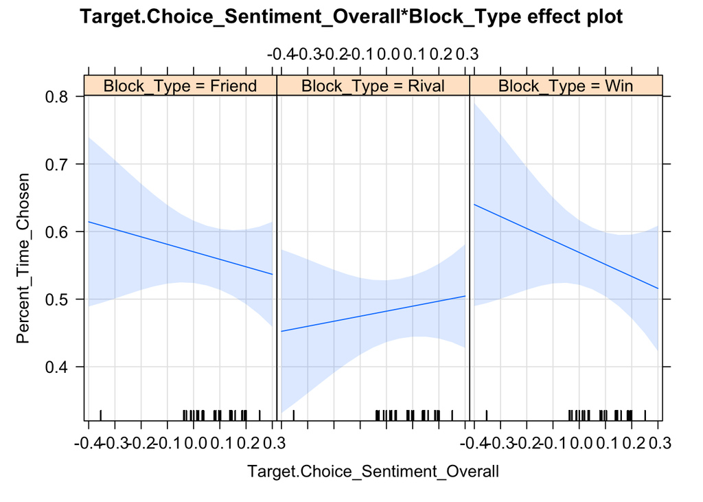

```r
plot(effect("Target.Choice_Sentiment_Overall:Block_Type", mlm2), grid = T)
```

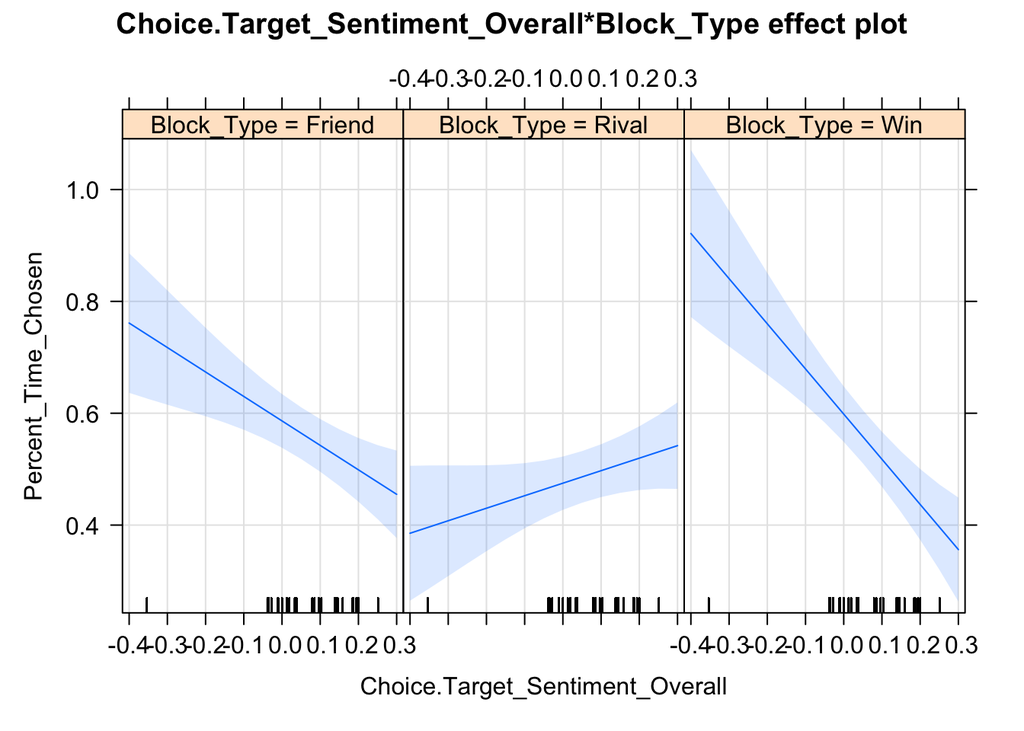

```r
plot(effect("Choice.Target_Sentiment_Overall:Block_Type", mlm3), grid = T)
```

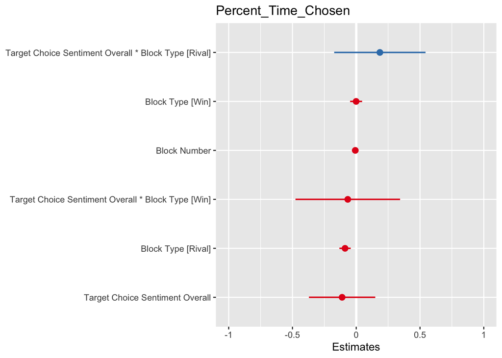

```r
plot_model(mlm2, sort.est = TRUE)
```

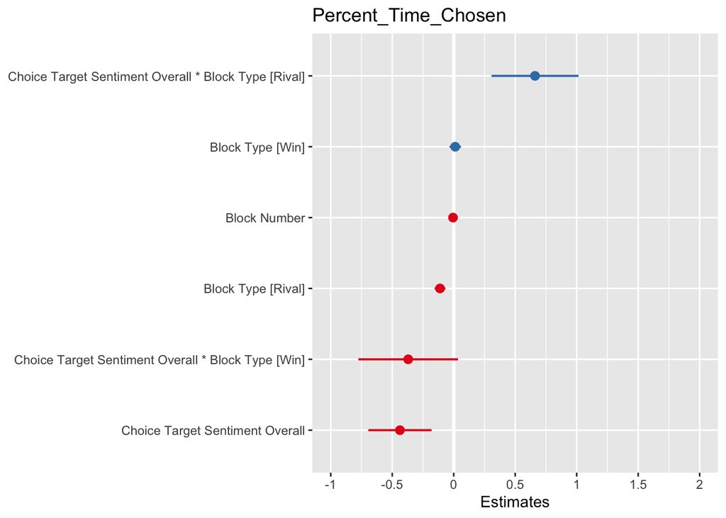

```r
plot_model(mlm3, sort.est = TRUE)
```

### Cumulative sentiment ~ % time chosen

How well does cumulative sentiment between target + choice predict percent of time chosen?

#### First, I’ll fit a linear mixed-effects model to my choice behavior + sentiment score data.

```r
## run the model
# How does cumulative sentiment predict percent of time chosen?
print("Target-Choice Model")
```

```
## [1] "Target-Choice Model"
```

```r
mlm2 <- lmer(Percent_Time_Chosen ~ Target.Choice_Sentiment_Cumulative * Block_Type + Block_Number + (Block_Type|PID) + (1|Block_Number), data = data)
# get coefficient estimates and coefficient SEs; pull error terms from group and residual to calculate ICC based on model output (intercept SD/intercept SD + residual SD)
display(mlm2)
```

```
## lmer(formula = Percent_Time_Chosen ~ Target.Choice_Sentiment_Cumulative *
##     Block_Type + Block_Number + (Block_Type | PID) + (1 | Block_Number),
##     data = data)
##                                                    coef.est coef.se
## (Intercept)                                         0.58     0.05
## Target.Choice_Sentiment_Cumulative                  0.33     0.11
## Block_TypeRival                                    -0.07     0.02
## Block_TypeWin                                       0.01     0.02
## Block_Number                                       -0.01     0.01
## Target.Choice_Sentiment_Cumulative:Block_TypeRival -0.57     0.15
## Target.Choice_Sentiment_Cumulative:Block_TypeWin   -0.41     0.17
##
## Error terms:
##  Groups       Name            Std.Dev. Corr
##  PID          (Intercept)     0.00
##               Block_TypeRival 0.00      0.81
##               Block_TypeWin   0.00     -0.61 -0.96
##  Block_Number (Intercept)     0.04
##  Residual                     0.33
## ---
## number of obs: 1564, groups: PID, 46; Block_Number, 5
## AIC = 1078.2, DIC = 981.9
## deviance = 1015.1
```

```r
print("Choice-Target Model")
```

```
## [1] "Choice-Target Model"
```

```r
mlm3 <- lmer(Percent_Time_Chosen ~ Choice.Target_Sentiment_Cumulative * Block_Type + Block_Number + (Block_Type|PID) + (1|Block_Number), data = data)
display(mlm3)
```

```
## lmer(formula = Percent_Time_Chosen ~ Choice.Target_Sentiment_Cumulative *
##     Block_Type + Block_Number + (Block_Type | PID) + (1 | Block_Number),
##     data = data)
##                                                    coef.est coef.se
## (Intercept)                                         0.59     0.05
## Choice.Target_Sentiment_Cumulative                 -0.06     0.11
## Block_TypeRival                                    -0.08     0.02
## Block_TypeWin                                       0.00     0.02
## Block_Number                                       -0.01     0.01
## Choice.Target_Sentiment_Cumulative:Block_TypeRival  0.15     0.15
## Choice.Target_Sentiment_Cumulative:Block_TypeWin   -0.24     0.17
##
## Error terms:
##  Groups       Name            Std.Dev. Corr
##  PID          (Intercept)     0.00
##               Block_TypeRival 0.00       NaN
##               Block_TypeWin   0.00       NaN -0.22
##  Block_Number (Intercept)     0.04
##  Residual                     0.34
## ---
## number of obs: 1564, groups: PID, 46; Block_Number, 5
## AIC = 1087.2, DIC = 991.3
## deviance = 1024.2
```

#### Now, I’ll get a summary table of my model showing the estimates for my fixed effects, standard error, df, t values, and significance levels.

```r
# get fixed effects table with estimate, SE, df, t value, and significance
print("Target-Choice Model")
```

```
## [1] "Target-Choice Model"
```

```r
summary(mlm2)
```

```
## Linear mixed model fit by REML. t-tests use Satterthwaite's method [
## lmerModLmerTest]
## Formula:
## Percent_Time_Chosen ~ Target.Choice_Sentiment_Cumulative * Block_Type +
##     Block_Number + (Block_Type | PID) + (1 | Block_Number)
##    Data: data
##
## REML criterion at convergence: 1048.2
##
## Scaled residuals:
##     Min      1Q  Median      3Q     Max
## -1.9106 -0.8358  0.0898  0.8123  1.7602
##
## Random effects:
##  Groups       Name            Variance  Std.Dev.  Corr
##  PID          (Intercept)     2.862e-10 1.692e-05
##               Block_TypeRival 1.673e-10 1.293e-05  0.81
##               Block_TypeWin   3.187e-11 5.645e-06 -0.61 -0.96
##  Block_Number (Intercept)     1.237e-03 3.517e-02
##  Residual                     1.121e-01 3.348e-01
## Number of obs: 1564, groups:  PID, 46; Block_Number, 5
##
## Fixed effects:
##                                                      Estimate Std. Error
## (Intercept)                                         5.835e-01  4.548e-02
## Target.Choice_Sentiment_Cumulative                  3.336e-01  1.077e-01
## Block_TypeRival                                    -6.694e-02  2.073e-02
## Block_TypeWin                                       5.006e-03  2.173e-02
## Block_Number                                       -8.364e-03  1.302e-02
## Target.Choice_Sentiment_Cumulative:Block_TypeRival -5.689e-01  1.506e-01
## Target.Choice_Sentiment_Cumulative:Block_TypeWin   -4.065e-01  1.692e-01
##                                                            df t value Pr(>|t|)
## (Intercept)                                         3.905e+00  12.829 0.000245
## Target.Choice_Sentiment_Cumulative                  1.556e+03   3.097 0.001988
## Block_TypeRival                                     1.554e+03  -3.228 0.001271
## Block_TypeWin                                       1.446e+03   0.230 0.817827
## Block_Number                                        3.191e+00  -0.642 0.563908
## Target.Choice_Sentiment_Cumulative:Block_TypeRival  1.554e+03  -3.777 0.000165
## Target.Choice_Sentiment_Cumulative:Block_TypeWin    1.556e+03  -2.403 0.016377
##
## (Intercept)                                        ***
## Target.Choice_Sentiment_Cumulative                 **
## Block_TypeRival                                    **
## Block_TypeWin
## Block_Number
## Target.Choice_Sentiment_Cumulative:Block_TypeRival ***
## Target.Choice_Sentiment_Cumulative:Block_TypeWin   *
## ---
## Signif. codes:  0 '***' 0.001 '**' 0.01 '*' 0.05 '.' 0.1 ' ' 1
##
## Correlation of Fixed Effects:
##              (Intr) Tr.C_S_C Blc_TR Blc_TW Blck_N T.C_S_C:B_TR
## Trgt.Ch_S_C  -0.022
## Blck_TypRvl  -0.234  0.109
## Block_TypWn  -0.256  0.101    0.486
## Block_Numbr  -0.878 -0.033    0.006  0.027
## T.C_S_C:B_TR  0.029 -0.712   -0.146 -0.079  0.009
## T.C_S_C:B_TW  0.043 -0.630   -0.075 -0.144 -0.009  0.452
## optimizer (nloptwrap) convergence code: 0 (OK)
## boundary (singular) fit: see ?isSingular
```

```r
print("Choice-Target Model")
```

```
## [1] "Choice-Target Model"
```

```r
summary(mlm3)
```

```
## Linear mixed model fit by REML. t-tests use Satterthwaite's method [
## lmerModLmerTest]
## Formula:
## Percent_Time_Chosen ~ Choice.Target_Sentiment_Cumulative * Block_Type +
##     Block_Number + (Block_Type | PID) + (1 | Block_Number)
##    Data: data
##
## REML criterion at convergence: 1057.2
##
## Scaled residuals:
##      Min       1Q   Median       3Q      Max
## -1.90290 -0.89593  0.08414  0.82008  1.74458
##
## Random effects:
##  Groups       Name            Variance  Std.Dev.  Corr
##  PID          (Intercept)     0.000e+00 0.000e+00
##               Block_TypeRival 1.592e-12 1.262e-06   NaN
##               Block_TypeWin   1.286e-11 3.586e-06   NaN -0.22
##  Block_Number (Intercept)     1.390e-03 3.728e-02
##  Residual                     1.127e-01 3.357e-01
## Number of obs: 1564, groups:  PID, 46; Block_Number, 5
##
## Fixed effects:
##                                                      Estimate Std. Error
## (Intercept)                                         5.871e-01  4.734e-02
## Choice.Target_Sentiment_Cumulative                 -5.689e-02  1.080e-01
## Block_TypeRival                                    -8.094e-02  2.080e-02
## Block_TypeWin                                       5.504e-05  2.180e-02
## Block_Number                                       -6.831e-03  1.361e-02
## Choice.Target_Sentiment_Cumulative:Block_TypeRival  1.473e-01  1.511e-01
## Choice.Target_Sentiment_Cumulative:Block_TypeWin   -2.352e-01  1.697e-01
##                                                            df t value Pr(>|t|)
## (Intercept)                                         3.841e+00  12.401 0.000307
## Choice.Target_Sentiment_Cumulative                  1.556e+03  -0.527 0.598482
## Block_TypeRival                                     1.555e+03  -3.892 0.000104
## Block_TypeWin                                       1.465e+03   0.003 0.997986
## Block_Number                                        3.185e+00  -0.502 0.648371
## Choice.Target_Sentiment_Cumulative:Block_TypeRival  1.554e+03   0.975 0.329537
## Choice.Target_Sentiment_Cumulative:Block_TypeWin    1.556e+03  -1.386 0.165886
##
## (Intercept)                                        ***
## Choice.Target_Sentiment_Cumulative
## Block_TypeRival                                    ***
## Block_TypeWin
## Block_Number
## Choice.Target_Sentiment_Cumulative:Block_TypeRival
## Choice.Target_Sentiment_Cumulative:Block_TypeWin
## ---
## Signif. codes:  0 '***' 0.001 '**' 0.01 '*' 0.05 '.' 0.1 ' ' 1
##
## Correlation of Fixed Effects:
##              (Intr) Ch.T_S_C Blc_TR Blc_TW Blck_N C.T_S_C:B_TR
## Chc.Trg_S_C  -0.021
## Blck_TypRvl  -0.226  0.109
## Block_TypWn  -0.247  0.101    0.485
## Block_Numbr  -0.880 -0.031    0.006  0.026
## C.T_S_C:B_TR  0.028 -0.712   -0.146 -0.079  0.009
## C.T_S_C:B_TW  0.042 -0.630   -0.076 -0.144 -0.008  0.452
## optimizer (nloptwrap) convergence code: 0 (OK)
## boundary (singular) fit: see ?isSingular
```

#### Now, I’ll examine the coefficients in my model.

```r
## examine the coefficients
print("Target-Choice Model")
```

```
## [1] "Target-Choice Model"
```

```r
coef(mlm2)
```

```
## $PID
##    (Intercept) Target.Choice_Sentiment_Cumulative Block_TypeRival Block_TypeWin
## 1    0.5834693                          0.3336122     -0.06693926   0.005005878
## 2    0.5834693                          0.3336122     -0.06693926   0.005005878
## 3    0.5834693                          0.3336122     -0.06693927   0.005005881
## 4    0.5834693                          0.3336122     -0.06693926   0.005005880
## 5    0.5834693                          0.3336122     -0.06693926   0.005005879
## 6    0.5834693                          0.3336122     -0.06693926   0.005005878
## 7    0.5834693                          0.3336122     -0.06693926   0.005005879
## 8    0.5834693                          0.3336122     -0.06693926   0.005005878
## 9    0.5834693                          0.3336122     -0.06693926   0.005005878
## 10   0.5834693                          0.3336122     -0.06693926   0.005005877
## 11   0.5834693                          0.3336122     -0.06693926   0.005005878
## 12   0.5834693                          0.3336122     -0.06693927   0.005005880
## 13   0.5834693                          0.3336122     -0.06693926   0.005005878
```

[output cut: 150 more lines]

```r
fixef(mlm2)
```

```
##                                        (Intercept)
##                                        0.583469318
##                 Target.Choice_Sentiment_Cumulative
##                                        0.333612151
##                                    Block_TypeRival
##                                       -0.066939261
##                                      Block_TypeWin
##                                        0.005005879
##                                       Block_Number
##                                       -0.008363975
## Target.Choice_Sentiment_Cumulative:Block_TypeRival
##                                       -0.568910597
##   Target.Choice_Sentiment_Cumulative:Block_TypeWin
##                                       -0.406545767
```

```r
ranef(mlm2)
```

```
## $PID
##      (Intercept) Block_TypeRival Block_TypeWin
## 1   2.365900e-09    1.557537e-09 -5.384492e-10
## 2   1.550997e-09    1.219018e-09 -4.688574e-10
## 3  -1.060647e-08   -6.559962e-09  2.166556e-09
## 4  -3.977228e-09   -2.778415e-09  9.988782e-10
## 5  -2.177352e-09   -1.738241e-09  6.739664e-10
## 6   1.777112e-09    2.289076e-09 -1.059530e-09
## 7  -1.543018e-09   -9.098700e-10  2.891604e-10
## 8   5.022985e-09    3.255939e-09 -1.113416e-09
## 9   4.716458e-09    3.050486e-09 -1.041513e-09
## 10  7.270993e-09    5.373236e-09 -1.998111e-09
## 11  3.893941e-09    2.291036e-09 -7.267360e-10
## 12 -6.684042e-09   -4.214614e-09  1.412523e-09
## 13  4.632123e-09    3.030759e-09 -1.043271e-09
```

[output cut: 43 more lines]

```r
se.fixef(mlm2)
```

```
##                                        (Intercept)
##                                         0.04547960
##                 Target.Choice_Sentiment_Cumulative
##                                         0.10771187
##                                    Block_TypeRival
##                                         0.02073475
##                                      Block_TypeWin
##                                         0.02172849
##                                       Block_Number
##                                         0.01302378
## Target.Choice_Sentiment_Cumulative:Block_TypeRival
##                                         0.15063227
##   Target.Choice_Sentiment_Cumulative:Block_TypeWin
##                                         0.16918130
```

```r
se.ranef(mlm2)
```

```
## $PID
##     (Intercept) Block_TypeRival Block_TypeWin
## 1  1.691597e-05    1.293337e-05  5.645447e-06
## 2  1.691597e-05    1.293337e-05  5.645447e-06
## 3  1.691597e-05    1.293337e-05  5.645447e-06
## 4  1.691597e-05    1.293337e-05  5.645447e-06
## 5  1.691597e-05    1.293337e-05  5.645447e-06
## 6  1.691597e-05    1.293337e-05  5.645447e-06
## 7  1.691597e-05    1.293337e-05  5.645447e-06
## 8  1.691597e-05    1.293337e-05  5.645447e-06
## 9  1.691597e-05    1.293337e-05  5.645447e-06
## 10 1.691597e-05    1.293337e-05  5.645447e-06
## 11 1.691597e-05    1.293337e-05  5.645447e-06
## 12 1.691597e-05    1.293337e-05  5.645447e-06
## 13 1.691597e-05    1.293337e-05  5.645447e-06
```

[output cut: 41 more lines]

```r
print("Choice-Target Model")
```

```
## [1] "Choice-Target Model"
```

```r
coef(mlm3)
```

```
## $PID
##    (Intercept) Choice.Target_Sentiment_Cumulative Block_TypeRival Block_TypeWin
## 1    0.5870953                        -0.05689184     -0.08094225  5.503945e-05
## 2    0.5870953                        -0.05689184     -0.08094225  5.503943e-05
## 3    0.5870953                        -0.05689184     -0.08094225  5.503921e-05
## 4    0.5870953                        -0.05689184     -0.08094225  5.503946e-05
## 5    0.5870953                        -0.05689184     -0.08094225  5.503939e-05
## 6    0.5870953                        -0.05689184     -0.08094225  5.503925e-05
## 7    0.5870953                        -0.05689184     -0.08094225  5.503932e-05
## 8    0.5870953                        -0.05689184     -0.08094225  5.503943e-05
## 9    0.5870953                        -0.05689184     -0.08094225  5.503949e-05
## 10   0.5870953                        -0.05689184     -0.08094225  5.503928e-05
## 11   0.5870953                        -0.05689184     -0.08094225  5.503946e-05
## 12   0.5870953                        -0.05689184     -0.08094225  5.503932e-05
## 13   0.5870953                        -0.05689184     -0.08094225  5.503948e-05
```

[output cut: 150 more lines]

```r
fixef(mlm3)
```

```
##                                        (Intercept)
##                                       5.870953e-01
##                 Choice.Target_Sentiment_Cumulative
##                                      -5.689184e-02
##                                    Block_TypeRival
##                                      -8.094225e-02
##                                      Block_TypeWin
##                                       5.503942e-05
##                                       Block_Number
##                                      -6.830926e-03
## Choice.Target_Sentiment_Cumulative:Block_TypeRival
##                                       1.473306e-01
##   Choice.Target_Sentiment_Cumulative:Block_TypeWin
##                                      -2.351797e-01
```

```r
ranef(mlm3)
```

```
## $PID
##    (Intercept) Block_TypeRival Block_TypeWin
## 1            0    2.710683e-12  3.166218e-11
## 2            0    7.214037e-12  8.355133e-12
## 3            0   -8.975766e-13 -2.084848e-10
## 4            0   -8.237378e-12  4.735874e-11
## 5            0   -1.032599e-11 -2.524537e-11
## 6            0    3.208245e-11 -1.641227e-10
## 7            0    2.094967e-12 -9.693860e-11
## 8            0    4.488504e-12  8.841053e-12
## 9            0    3.654149e-12  7.580006e-11
## 10           0    2.581715e-11 -1.361985e-10
## 11           0   -1.887412e-12  3.980293e-11
## 12           0   -2.963714e-12 -9.375641e-11
## 13           0    4.450468e-12  6.108016e-11
```

[output cut: 43 more lines]

```r
se.fixef(mlm3)
```

```
##                                        (Intercept)
##                                         0.04734205
##                 Choice.Target_Sentiment_Cumulative
##                                         0.10801713
##                                    Block_TypeRival
##                                         0.02079584
##                                      Block_TypeWin
##                                         0.02180170
##                                       Block_Number
##                                         0.01360894
## Choice.Target_Sentiment_Cumulative:Block_TypeRival
##                                         0.15105358
##   Choice.Target_Sentiment_Cumulative:Block_TypeWin
##                                         0.16965843
```

```r
se.ranef(mlm3)
```

```
## $PID
##    (Intercept) Block_TypeRival Block_TypeWin
## 1            0    1.261909e-06   3.58589e-06
## 2            0    1.261909e-06   3.58589e-06
## 3            0    1.261909e-06   3.58589e-06
## 4            0    1.261909e-06   3.58589e-06
## 5            0    1.261909e-06   3.58589e-06
## 6            0    1.261909e-06   3.58589e-06
## 7            0    1.261909e-06   3.58589e-06
## 8            0    1.261909e-06   3.58589e-06
## 9            0    1.261909e-06   3.58589e-06
## 10           0    1.261909e-06   3.58589e-06
## 11           0    1.261909e-06   3.58589e-06
## 12           0    1.261909e-06   3.58589e-06
## 13           0    1.261909e-06   3.58589e-06
```

[output cut: 41 more lines]

#### Now, I’m going to test my model against a null model.

```r
## test the model against the null model
# create the null model
print("Create null model for target-choice - comparing to a model without the block type interaction term")
```

```
## [1] "Create null model for target-choice - comparing to a model without the block type interaction term"
```

```r
null.mlm2 <- lmer(Percent_Time_Chosen ~ Target.Choice_Sentiment_Cumulative + Block_Type + Block_Number + (Block_Type|PID) + (1|Block_Number), data = data)
display(null.mlm2)
```

```
## lmer(formula = Percent_Time_Chosen ~ Target.Choice_Sentiment_Cumulative +
##     Block_Type + Block_Number + (Block_Type | PID) + (1 | Block_Number),
##     data = data)
##                                    coef.est coef.se
## (Intercept)                         0.59     0.05
## Target.Choice_Sentiment_Cumulative  0.02     0.07
## Block_TypeRival                    -0.08     0.02
## Block_TypeWin                       0.00     0.02
## Block_Number                       -0.01     0.01
##
## Error terms:
##  Groups       Name            Std.Dev. Corr
##  PID          (Intercept)     0.00
##               Block_TypeRival 0.00      NaN
##               Block_TypeWin   0.00      NaN 1.00
##  Block_Number (Intercept)     0.04
##  Residual                     0.34
## ---
## number of obs: 1564, groups: PID, 46; Block_Number, 5
## AIC = 1085.2, DIC = 1000.7
## deviance = 1029.9
```

```r
print("Create null model for choice-target - comparing to a model without the block type interaction term")
```

```
## [1] "Create null model for choice-target - comparing to a model without the block type interaction term"
```

```r
null.mlm3 <- lmer(Percent_Time_Chosen ~ Choice.Target_Sentiment_Cumulative + Block_Type + Block_Number + (Block_Type|PID) + (1|Block_Number), data = data)
display(null.mlm3)
```

```
## lmer(formula = Percent_Time_Chosen ~ Choice.Target_Sentiment_Cumulative +
##     Block_Type + Block_Number + (Block_Type | PID) + (1 | Block_Number),
##     data = data)
##                                    coef.est coef.se
## (Intercept)                         0.59     0.05
## Choice.Target_Sentiment_Cumulative -0.06     0.07
## Block_TypeRival                    -0.08     0.02
## Block_TypeWin                       0.00     0.02
## Block_Number                       -0.01     0.01
##
## Error terms:
##  Groups       Name            Std.Dev. Corr
##  PID          (Intercept)     0.00
##               Block_TypeRival 0.00     -0.19
##               Block_TypeWin   0.00     -0.90  0.59
##  Block_Number (Intercept)     0.04
##  Residual                     0.34
## ---
## number of obs: 1564, groups: PID, 46; Block_Number, 5
## AIC = 1084.4, DIC = 1000.2
## deviance = 1029.3
```

#### Finally, I can compare my model to the null model by running an ANOVA.

```r
# test our model against the null model
print("Target-Choice Model")
```

```
## [1] "Target-Choice Model"
```

```r
anova(null.mlm2, mlm2)
```

|  | npar | AIC | BIC | logLik | deviance | Chisq | Df | Pr(>Chisq) |
| --- | --- | --- | --- | --- | --- | --- | --- | --- |
| null.mlm2 | 13 | 1055.934 | 1125.549 | -514.9669 | 1029.934 | NA | NA | NA |
| mlm2 | 15 | 1045.086 | 1125.411 | -507.5428 | 1015.086 | 14.84825 | 2 | 0.0005966834 |

```r
print("Choice-Target Model")
```

```
## [1] "Choice-Target Model"
```

```r
anova(null.mlm3, mlm3)
```

|  | npar | AIC | BIC | logLik | deviance | Chisq | Df | Pr(>Chisq) |
| --- | --- | --- | --- | --- | --- | --- | --- | --- |
| null.mlm3 | 13 | 1055.330 | 1124.945 | -514.6648 | 1029.330 | NA | NA | NA |
| mlm3 | 15 | 1054.243 | 1134.568 | -512.1214 | 1024.243 | 5.086737 | 2 | 0.0786012 |

### Plot!

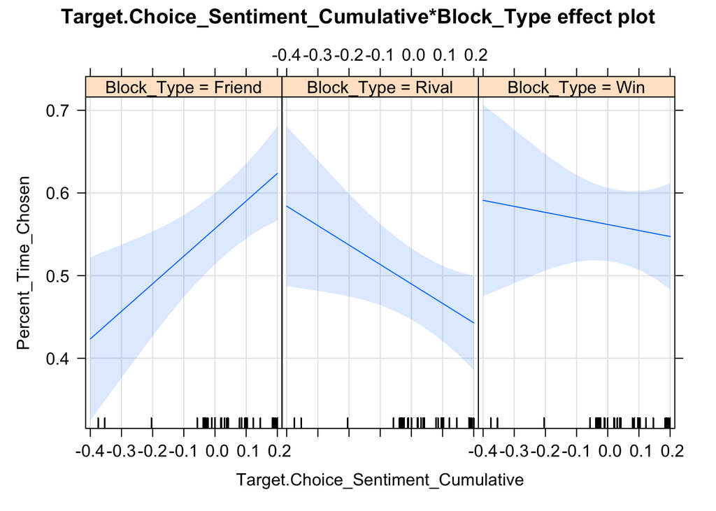

```r
plot(effect("Target.Choice_Sentiment_Cumulative:Block_Type", mlm2), grid = T)
```

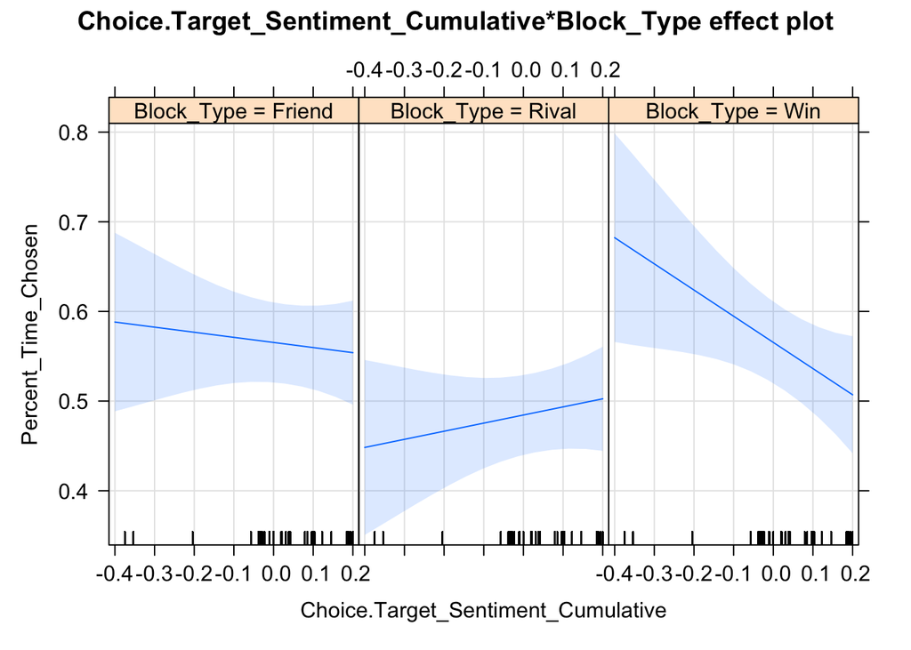

```r
plot(effect("Choice.Target_Sentiment_Cumulative:Block_Type", mlm3), grid = T)
```

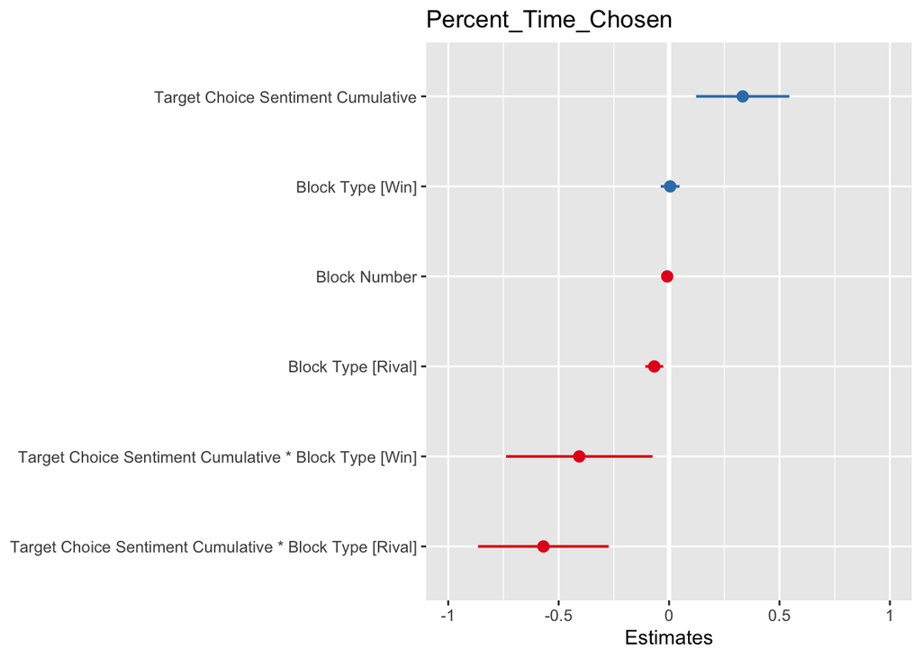

```r
plot_model(mlm2, sort.est = TRUE)
```

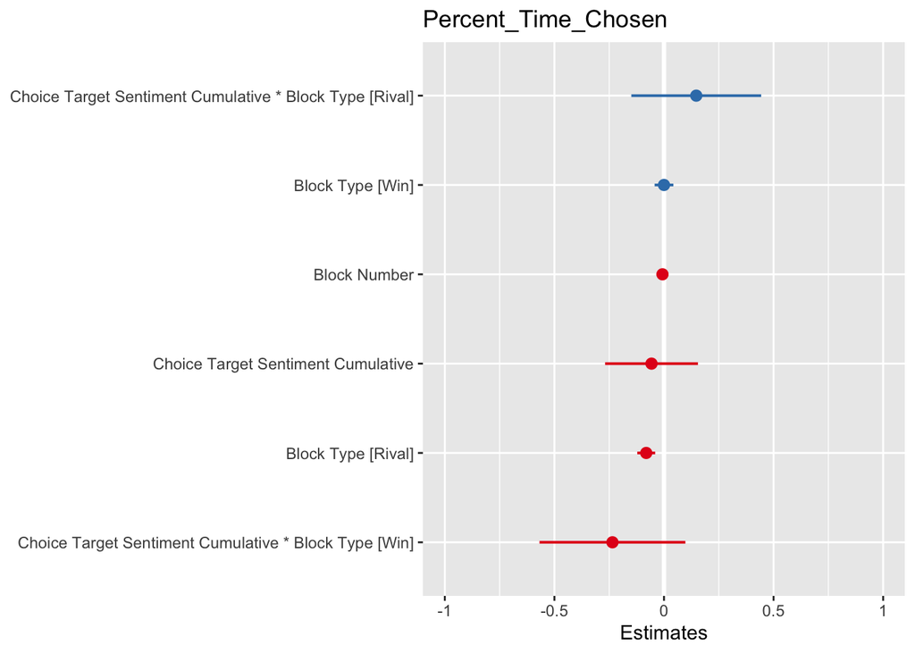

```r
plot_model(mlm3, sort.est = TRUE)
```

### Most recent sentiment ~ % time chosen

How well does most recent sentiment between target + choice predict percent of time chosen?

#### First, I’ll fit a linear mixed-effects model to my choice behavior + sentiment score data.

```r
## run the model
# How does most recent sentiment predict percent of time chosen?
print("Target-Choice Model")
```

```
## [1] "Target-Choice Model"
```

```r
mlm2 <- lmer(Percent_Time_Chosen ~ Target.Choice_Sentiment_Recent * Block_Type + Block_Number + (Block_Type|PID) + (1|Block_Number), data = data)
# get coefficient estimates and coefficient SEs; pull error terms from group and residual to calculate ICC based on model output (intercept SD/intercept SD + residual SD)
display(mlm2)
```

```
## lmer(formula = Percent_Time_Chosen ~ Target.Choice_Sentiment_Recent *
##     Block_Type + Block_Number + (Block_Type | PID) + (1 | Block_Number),
##     data = data)
##                                                coef.est coef.se
## (Intercept)                                     0.58     0.05
## Target.Choice_Sentiment_Recent                  0.42     0.10
## Block_TypeRival                                -0.05     0.02
## Block_TypeWin                                   0.01     0.02
## Block_Number                                   -0.01     0.01
## Target.Choice_Sentiment_Recent:Block_TypeRival -0.67     0.14
## Target.Choice_Sentiment_Recent:Block_TypeWin   -0.46     0.16
##
## Error terms:
##  Groups       Name            Std.Dev. Corr
##  PID          (Intercept)     0.00
##               Block_TypeRival 0.00     -1.00
##               Block_TypeWin   0.00     -0.92  0.92
##  Block_Number (Intercept)     0.04
##  Residual                     0.33
## ---
## number of obs: 1564, groups: PID, 46; Block_Number, 5
## AIC = 1069.6, DIC = 972.6
## deviance = 1006.1
```

```r
print("Choice-Target Model")
```

```
## [1] "Choice-Target Model"
```

```r
mlm3 <- lmer(Percent_Time_Chosen ~ Choice.Target_Sentiment_Recent * Block_Type + Block_Number + (Block_Type|PID) + (1|Block_Number), data = data)
display(mlm3)
```

```
## lmer(formula = Percent_Time_Chosen ~ Choice.Target_Sentiment_Recent *
##     Block_Type + Block_Number + (Block_Type | PID) + (1 | Block_Number),
##     data = data)
##                                                coef.est coef.se
## (Intercept)                                     0.59     0.05
## Choice.Target_Sentiment_Recent                  0.13     0.10
## Block_TypeRival                                -0.07     0.02
## Block_TypeWin                                   0.00     0.02
## Block_Number                                   -0.01     0.01
## Choice.Target_Sentiment_Recent:Block_TypeRival -0.16     0.14
## Choice.Target_Sentiment_Recent:Block_TypeWin   -0.15     0.16
##
## Error terms:
##  Groups       Name            Std.Dev. Corr
##  PID          (Intercept)     0.00
##               Block_TypeRival 0.00      0.12
##               Block_TypeWin   0.00     -0.88  0.37
##  Block_Number (Intercept)     0.04
##  Residual                     0.34
## ---
## number of obs: 1564, groups: PID, 46; Block_Number, 5
## AIC = 1091.7, DIC = 994.8
## deviance = 1028.2
```

#### Now, I’ll get a summary table of my model showing the estimates for my fixed effects, standard error, df, t values, and significance levels.

```r
# get fixed effects table with estimate, SE, df, t value, and significance
print("Target-Choice Model")
```

```
## [1] "Target-Choice Model"
```

```r
summary(mlm2)
```

```
## Linear mixed model fit by REML. t-tests use Satterthwaite's method [
## lmerModLmerTest]
## Formula: Percent_Time_Chosen ~ Target.Choice_Sentiment_Recent * Block_Type +
##     Block_Number + (Block_Type | PID) + (1 | Block_Number)
##    Data: data
##
## REML criterion at convergence: 1039.6
##
## Scaled residuals:
##      Min       1Q   Median       3Q      Max
## -1.93977 -0.82530  0.06966  0.81786  1.77414
##
## Random effects:
##  Groups       Name            Variance  Std.Dev.  Corr
##  PID          (Intercept)     1.477e-10 1.215e-05
##               Block_TypeRival 1.272e-11 3.566e-06 -1.00
##               Block_TypeWin   2.093e-10 1.447e-05 -0.92  0.92
##  Block_Number (Intercept)     1.230e-03 3.507e-02
##  Residual                     1.114e-01 3.338e-01
## Number of obs: 1564, groups:  PID, 46; Block_Number, 5
##
## Fixed effects:
##                                                  Estimate Std. Error         df
## (Intercept)                                     5.771e-01  4.540e-02  3.913e+00
## Target.Choice_Sentiment_Recent                  4.199e-01  1.015e-01  1.557e+03
## Block_TypeRival                                -5.494e-02  2.104e-02  1.554e+03
## Block_TypeWin                                   1.260e-02  2.199e-02  1.442e+03
## Block_Number                                   -8.818e-03  1.298e-02  3.178e+00
## Target.Choice_Sentiment_Recent:Block_TypeRival -6.738e-01  1.413e-01  1.554e+03
## Target.Choice_Sentiment_Recent:Block_TypeWin   -4.602e-01  1.601e-01  1.556e+03
##                                                t value Pr(>|t|)
## (Intercept)                                     12.712 0.000251 ***
## Target.Choice_Sentiment_Recent                   4.135 3.74e-05 ***
## Block_TypeRival                                 -2.612 0.009088 **
## Block_TypeWin                                    0.573 0.566864
## Block_Number                                    -0.679 0.543233
## Target.Choice_Sentiment_Recent:Block_TypeRival  -4.770 2.02e-06 ***
## Target.Choice_Sentiment_Recent:Block_TypeWin    -2.875 0.004100 **
## ---
## Signif. codes:  0 '***' 0.001 '**' 0.01 '*' 0.05 '.' 0.1 ' ' 1
##
## Correlation of Fixed Effects:
##              (Intr) Tr.C_S_R Blc_TR Blc_TW Blck_N T.C_S_R:B_TR
## Trgt.Ch_S_R  -0.053
## Blck_TypRvl  -0.237  0.171
## Block_TypWn  -0.261  0.155    0.488
## Block_Numbr  -0.876 -0.029    0.005  0.028
## T.C_S_R:B_TR  0.048 -0.713   -0.234 -0.122  0.011
## T.C_S_R:B_TW  0.066 -0.625   -0.114 -0.221 -0.013  0.452
## optimizer (nloptwrap) convergence code: 0 (OK)
## boundary (singular) fit: see ?isSingular
```

```r
print("Choice-Target Model")
```

```
## [1] "Choice-Target Model"
```

```r
summary(mlm3)
```

```
## Linear mixed model fit by REML. t-tests use Satterthwaite's method [
## lmerModLmerTest]
## Formula: Percent_Time_Chosen ~ Choice.Target_Sentiment_Recent * Block_Type +
##     Block_Number + (Block_Type | PID) + (1 | Block_Number)
##    Data: data
##
## REML criterion at convergence: 1061.7
##
## Scaled residuals:
##      Min       1Q   Median       3Q      Max
## -1.83095 -0.86183  0.07507  0.82368  1.64915
##
## Random effects:
##  Groups       Name            Variance  Std.Dev.  Corr
##  PID          (Intercept)     1.529e-11 3.910e-06
##               Block_TypeRival 2.955e-10 1.719e-05  0.12
##               Block_TypeWin   5.432e-11 7.370e-06 -0.88  0.37
##  Block_Number (Intercept)     1.232e-03 3.510e-02
##  Residual                     1.130e-01 3.362e-01
## Number of obs: 1564, groups:  PID, 46; Block_Number, 5
##
## Fixed effects:
##                                                  Estimate Std. Error         df
## (Intercept)                                     5.858e-01  4.554e-02  3.939e+00
## Choice.Target_Sentiment_Recent                  1.304e-01  1.023e-01  1.557e+03
## Block_TypeRival                                -7.292e-02  2.118e-02  1.554e+03
## Block_TypeWin                                   1.615e-03  2.214e-02  1.440e+03
## Block_Number                                   -8.214e-03  1.302e-02  3.194e+00
## Choice.Target_Sentiment_Recent:Block_TypeRival -1.592e-01  1.423e-01  1.554e+03
## Choice.Target_Sentiment_Recent:Block_TypeWin   -1.548e-01  1.612e-01  1.556e+03
##                                                t value Pr(>|t|)
## (Intercept)                                     12.864 0.000231 ***
## Choice.Target_Sentiment_Recent                   1.276 0.202263
## Block_TypeRival                                 -3.442 0.000592 ***
## Block_TypeWin                                    0.073 0.941877
## Block_Number                                    -0.631 0.570303
## Choice.Target_Sentiment_Recent:Block_TypeRival  -1.119 0.263365
## Choice.Target_Sentiment_Recent:Block_TypeWin    -0.960 0.336986
## ---
## Signif. codes:  0 '***' 0.001 '**' 0.01 '*' 0.05 '.' 0.1 ' ' 1
##
## Correlation of Fixed Effects:
##              (Intr) Ch.T_S_R Blc_TR Blc_TW Blck_N C.T_S_R:B_TR
## Chc.Trg_S_R  -0.053
## Blck_TypRvl  -0.238  0.171
## Block_TypWn  -0.262  0.155    0.488
## Block_Numbr  -0.876 -0.029    0.005  0.028
## C.T_S_R:B_TR  0.049 -0.713   -0.234 -0.122  0.011
## C.T_S_R:B_TW  0.066 -0.625   -0.114 -0.221 -0.013  0.452
## optimizer (nloptwrap) convergence code: 0 (OK)
## boundary (singular) fit: see ?isSingular
```

#### Now, I’ll examine the coefficients in my model.

```r
## examine the coefficients
print("Target-Choice Model")
```

```
## [1] "Target-Choice Model"
```

```r
coef(mlm2)
```

```
## $PID
##    (Intercept) Target.Choice_Sentiment_Recent Block_TypeRival Block_TypeWin
## 1    0.5771459                      0.4198786     -0.05494409    0.01259511
## 2    0.5771459                      0.4198786     -0.05494409    0.01259511
## 3    0.5771459                      0.4198786     -0.05494409    0.01259512
## 4    0.5771459                      0.4198786     -0.05494409    0.01259512
## 5    0.5771459                      0.4198786     -0.05494409    0.01259511
## 6    0.5771459                      0.4198786     -0.05494409    0.01259511
## 7    0.5771459                      0.4198786     -0.05494409    0.01259511
## 8    0.5771459                      0.4198786     -0.05494409    0.01259511
## 9    0.5771459                      0.4198786     -0.05494409    0.01259511
## 10   0.5771459                      0.4198786     -0.05494409    0.01259511
## 11   0.5771459                      0.4198786     -0.05494409    0.01259511
## 12   0.5771459                      0.4198786     -0.05494409    0.01259512
## 13   0.5771459                      0.4198786     -0.05494409    0.01259511
```

[output cut: 150 more lines]

```r
fixef(mlm2)
```

```
##                                    (Intercept)
##                                    0.577145865
##                 Target.Choice_Sentiment_Recent
##                                    0.419878560
##                                Block_TypeRival
##                                   -0.054944092
##                                  Block_TypeWin
##                                    0.012595115
##                                   Block_Number
##                                   -0.008817891
## Target.Choice_Sentiment_Recent:Block_TypeRival
##                                   -0.673792468
##   Target.Choice_Sentiment_Recent:Block_TypeWin
##                                   -0.460156626
```

```r
ranef(mlm2)
```

```
## $PID
##      (Intercept) Block_TypeRival Block_TypeWin
## 1   3.909253e-10   -1.147285e-10 -3.363924e-10
## 2  -1.325003e-11    3.888610e-12  5.416358e-11
## 3  -1.870354e-09    5.489101e-10  1.509495e-09
## 4  -2.007476e-09    5.891525e-10  2.312069e-09
## 5   3.111814e-10   -9.132530e-11 -4.188118e-10
## 6   5.598307e-10   -1.642987e-10 -9.869150e-10
## 7   7.778756e-10   -2.282903e-10 -1.097021e-09
## 8   2.006893e-09   -5.889815e-10 -2.166019e-09
## 9   7.612422e-10   -2.234088e-10 -6.399731e-10
## 10  3.787711e-09   -1.111615e-09 -4.471485e-09
## 11  1.611597e-09   -4.729704e-10 -1.669556e-09
## 12 -1.686978e-09    4.950930e-10  1.607338e-09
## 13  9.529747e-10   -2.796783e-10 -8.794067e-10
```

[output cut: 43 more lines]

```r
se.fixef(mlm2)
```

```
##                                    (Intercept)
##                                     0.04540302
##                 Target.Choice_Sentiment_Recent
##                                     0.10153736
##                                Block_TypeRival
##                                     0.02103507
##                                  Block_TypeWin
##                                     0.02198837
##                                   Block_Number
##                                     0.01298384
## Target.Choice_Sentiment_Recent:Block_TypeRival
##                                     0.14126240
##   Target.Choice_Sentiment_Recent:Block_TypeWin
##                                     0.16007581
```

```r
se.ranef(mlm2)
```

```
## $PID
##     (Intercept) Block_TypeRival Block_TypeWin
## 1  1.215134e-05    3.566165e-06  1.446711e-05
## 2  1.215134e-05    3.566165e-06  1.446711e-05
## 3  1.215134e-05    3.566165e-06  1.446711e-05
## 4  1.215134e-05    3.566165e-06  1.446711e-05
## 5  1.215134e-05    3.566165e-06  1.446711e-05
## 6  1.215134e-05    3.566165e-06  1.446711e-05
## 7  1.215134e-05    3.566165e-06  1.446711e-05
## 8  1.215134e-05    3.566165e-06  1.446711e-05
## 9  1.215134e-05    3.566165e-06  1.446711e-05
## 10 1.215134e-05    3.566165e-06  1.446711e-05
## 11 1.215134e-05    3.566165e-06  1.446711e-05
## 12 1.215134e-05    3.566165e-06  1.446711e-05
## 13 1.215134e-05    3.566165e-06  1.446711e-05
```

[output cut: 41 more lines]

```r
print("Choice-Target Model")
```

```
## [1] "Choice-Target Model"
```

```r
coef(mlm3)
```

```
## $PID
##    (Intercept) Choice.Target_Sentiment_Recent Block_TypeRival Block_TypeWin
## 1    0.5858115                      0.1304471     -0.07292307   0.001614752
## 2    0.5858115                      0.1304471     -0.07292307   0.001614752
## 3    0.5858115                      0.1304471     -0.07292307   0.001614751
## 4    0.5858115                      0.1304471     -0.07292307   0.001614752
## 5    0.5858115                      0.1304471     -0.07292307   0.001614751
## 6    0.5858115                      0.1304471     -0.07292306   0.001614751
## 7    0.5858115                      0.1304471     -0.07292307   0.001614751
## 8    0.5858115                      0.1304471     -0.07292307   0.001614751
## 9    0.5858115                      0.1304471     -0.07292307   0.001614752
## 10   0.5858115                      0.1304471     -0.07292307   0.001614751
## 11   0.5858115                      0.1304471     -0.07292307   0.001614751
## 12   0.5858115                      0.1304471     -0.07292307   0.001614751
## 13   0.5858115                      0.1304471     -0.07292307   0.001614752
```

[output cut: 150 more lines]

```r
fixef(mlm3)
```

```
##                                    (Intercept)
##                                    0.585811537
##                 Choice.Target_Sentiment_Recent
##                                    0.130447124
##                                Block_TypeRival
##                                   -0.072923068
##                                  Block_TypeWin
##                                    0.001614751
##                                   Block_Number
##                                   -0.008213735
## Choice.Target_Sentiment_Recent:Block_TypeRival
##                                   -0.159178578
##   Choice.Target_Sentiment_Recent:Block_TypeWin
##                                   -0.154834198
```

```r
ranef(mlm3)
```

```
## $PID
##      (Intercept) Block_TypeRival Block_TypeWin
## 1   6.116197e-11    1.212280e-09  1.435246e-10
## 2   5.198405e-11    1.618903e-09  2.439417e-10
## 3  -1.828854e-10   -4.255288e-09 -5.597835e-10
## 4  -2.720571e-10   -8.793830e-10  2.967493e-10
## 5  -4.404976e-11   -2.515084e-09 -4.436135e-10
## 6   3.227734e-10    3.272280e-09  1.098082e-10
## 7   1.008224e-10   -1.468308e-09 -4.817602e-10
## 8   2.411593e-10    1.198185e-09 -1.762912e-10
## 9   1.016455e-10    2.204856e-09  2.779286e-10
## 10  6.008084e-10    2.501376e-09 -5.394311e-10
## 11  1.520057e-10    3.403975e-10 -1.970786e-10
## 12 -1.853596e-10   -2.420906e-09 -1.753145e-10
## 13  1.207147e-10    2.156039e-09  2.342407e-10
```

[output cut: 43 more lines]

```r
se.fixef(mlm3)
```

```
##                                    (Intercept)
##                                     0.04553748
##                 Choice.Target_Sentiment_Recent
##                                     0.10225787
##                                Block_TypeRival
##                                     0.02118419
##                                  Block_TypeWin
##                                     0.02214313
##                                   Block_Number
##                                     0.01301638
## Choice.Target_Sentiment_Recent:Block_TypeRival
##                                     0.14226621
##   Choice.Target_Sentiment_Recent:Block_TypeWin
##                                     0.16121267
```

```r
se.ranef(mlm3)
```

```
## $PID
##     (Intercept) Block_TypeRival Block_TypeWin
## 1  3.909733e-06    1.719018e-05  7.370159e-06
## 2  3.909733e-06    1.719018e-05  7.370159e-06
## 3  3.909733e-06    1.719018e-05  7.370159e-06
## 4  3.909733e-06    1.719018e-05  7.370159e-06
## 5  3.909733e-06    1.719018e-05  7.370159e-06
## 6  3.909733e-06    1.719018e-05  7.370159e-06
## 7  3.909733e-06    1.719018e-05  7.370159e-06
## 8  3.909733e-06    1.719018e-05  7.370159e-06
## 9  3.909733e-06    1.719018e-05  7.370159e-06
## 10 3.909733e-06    1.719018e-05  7.370159e-06
## 11 3.909733e-06    1.719018e-05  7.370159e-06
## 12 3.909733e-06    1.719018e-05  7.370159e-06
## 13 3.909733e-06    1.719018e-05  7.370159e-06
```

[output cut: 41 more lines]

#### Now, I’m going to test my model against a null model.

```r
## test the model against the null model
# create the null model
print("Create null model for target-choice - comparing to a model without the block type interaction term")
```

```
## [1] "Create null model for target-choice - comparing to a model without the block type interaction term"
```

```r
null.mlm2 <- lmer(Percent_Time_Chosen ~ Target.Choice_Sentiment_Recent + Block_Type + Block_Number + (Block_Type|PID) + (1|Block_Number), data = data)
display(null.mlm2)
```

```
## lmer(formula = Percent_Time_Chosen ~ Target.Choice_Sentiment_Recent +
##     Block_Type + Block_Number + (Block_Type | PID) + (1 | Block_Number),
##     data = data)
##                                coef.est coef.se
## (Intercept)                     0.59     0.05
## Target.Choice_Sentiment_Recent  0.05     0.06
## Block_TypeRival                -0.08     0.02
## Block_TypeWin                   0.00     0.02
## Block_Number                   -0.01     0.01
##
## Error terms:
##  Groups       Name            Std.Dev. Corr
##  PID          (Intercept)     0.00
##               Block_TypeRival 0.00      0.08
##               Block_TypeWin   0.00     -0.98 -0.05
##  Block_Number (Intercept)     0.03
##  Residual                     0.34
## ---
## number of obs: 1564, groups: PID, 46; Block_Number, 5
## AIC = 1084.8, DIC = 1000
## deviance = 1029.4
```

```r
print("Create null model for choice-target - comparing to a model without the block type interaction term")
```

```
## [1] "Create null model for choice-target - comparing to a model without the block type interaction term"
```

```r
null.mlm3 <- lmer(Percent_Time_Chosen ~ Choice.Target_Sentiment_Recent + Block_Type + Block_Number + (Block_Type|PID) + (1|Block_Number), data = data)
display(null.mlm3)
```

```
## lmer(formula = Percent_Time_Chosen ~ Choice.Target_Sentiment_Recent +
##     Block_Type + Block_Number + (Block_Type | PID) + (1 | Block_Number),
##     data = data)
##                                coef.est coef.se
## (Intercept)                     0.59     0.05
## Choice.Target_Sentiment_Recent  0.03     0.06
## Block_TypeRival                -0.08     0.02
## Block_TypeWin                   0.00     0.02
## Block_Number                   -0.01     0.01
##
## Error terms:
##  Groups       Name            Std.Dev. Corr
##  PID          (Intercept)     0.00
##               Block_TypeRival 0.00      0.89
##               Block_TypeWin   0.00     -0.70 -0.83
##  Block_Number (Intercept)     0.03
##  Residual                     0.34
## ---
## number of obs: 1564, groups: PID, 46; Block_Number, 5
## AIC = 1085.1, DIC = 1000.4
## deviance = 1029.7
```

#### Finally, I can compare my model to the null model by running an ANOVA.

```r
# test our model against the null model
print("Target-Choice Model")
```

```
## [1] "Target-Choice Model"
```

```r
anova(null.mlm2, mlm2)
```

|  | npar | AIC | BIC | logLik | deviance | Chisq | Df | Pr(>Chisq) |
| --- | --- | --- | --- | --- | --- | --- | --- | --- |
| null.mlm2 | 13 | 1055.386 | 1125.001 | -514.693 | 1029.386 | NA | NA | NA |
| mlm2 | 15 | 1036.112 | 1116.437 | -503.056 | 1006.112 | 23.27417 | 2 | 8.832371e-06 |

```r
print("Choice-Target Model")
```

```
## [1] "Choice-Target Model"
```

```r
anova(null.mlm3, mlm3)
```

|  | npar | AIC | BIC | logLik | deviance | Chisq | Df | Pr(>Chisq) |
| --- | --- | --- | --- | --- | --- | --- | --- | --- |
| null.mlm3 | 13 | 1055.718 | 1125.333 | -514.8592 | 1029.718 | NA | NA | NA |
| mlm3 | 15 | 1058.218 | 1138.543 | -514.1088 | 1028.218 | 1.50094 | 2 | 0.4721445 |

### Plot!

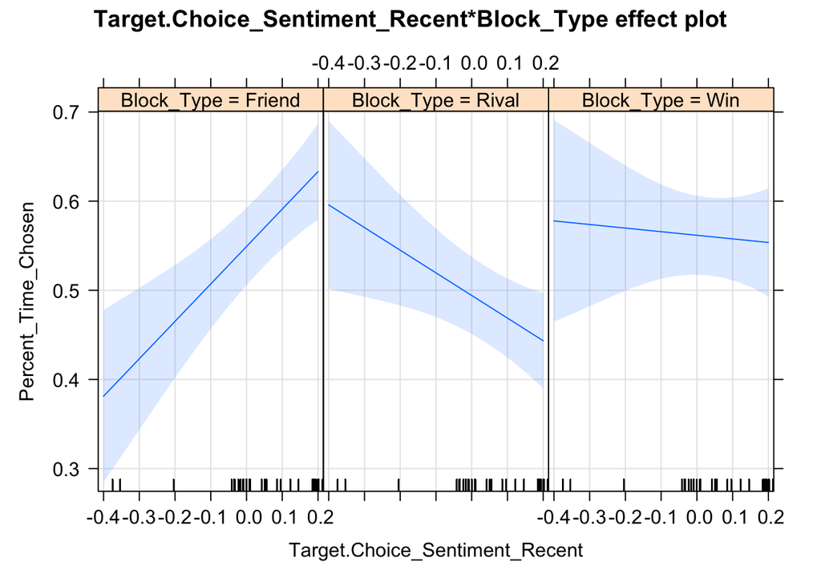

```r
plot(effect("Target.Choice_Sentiment_Recent:Block_Type", mlm2), grid = T)
```

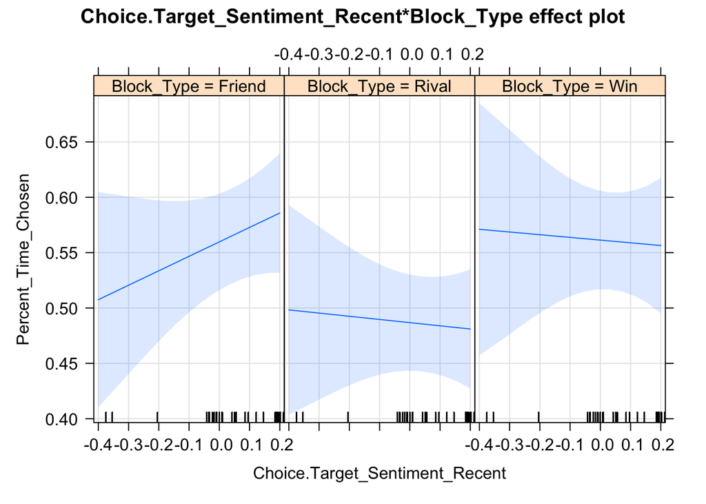

```r
plot(effect("Choice.Target_Sentiment_Recent:Block_Type", mlm3), grid = T)
```

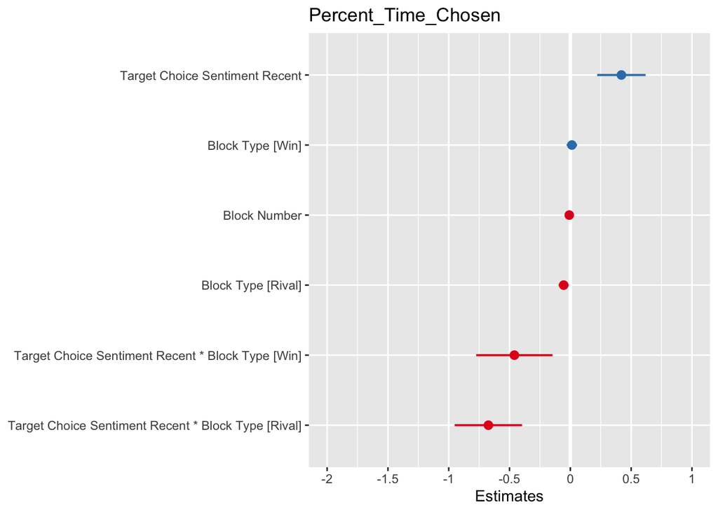

```r
plot_model(mlm2, sort.est = TRUE)
```

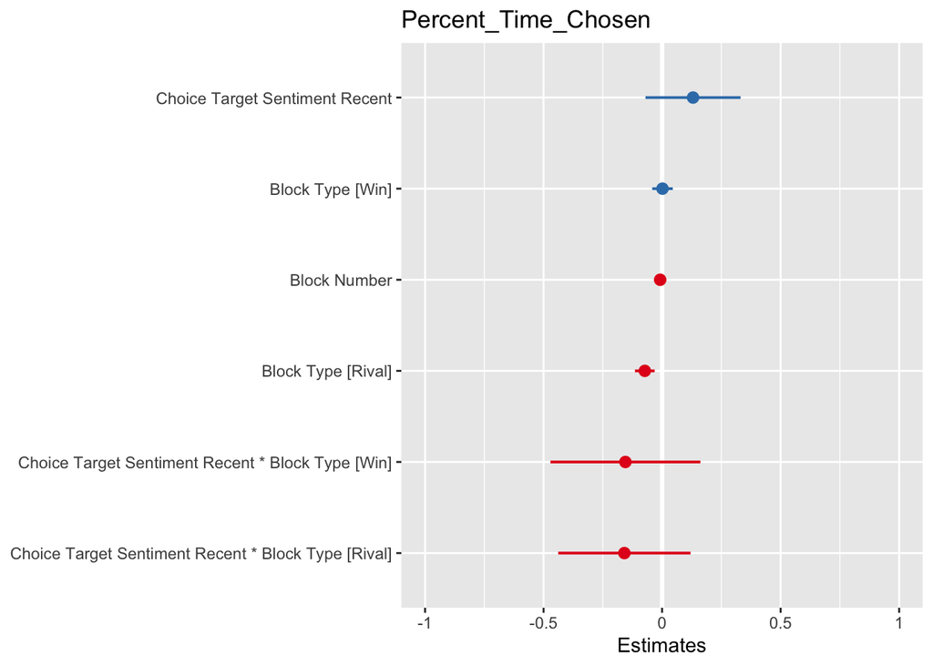

```r
plot_model(mlm3, sort.est = TRUE)
```